# Assignment 2

Supervised Machine Learning Fundamentals

Aesha Gandhi  
2026-01-21

```python
%pip -q install pandas
%pip -q install scikit-learn
%pip -q install ucimlrepo
%pip -q install nbconvert
```

```python
import numpy
import pandas as pd
from sklearn.datasets import make_moons
from sklearn.model_selection import train_test_split
from sklearn.neighbors import KNeighborsClassifier
from sklearn.metrics import accuracy_score as accuracy
```

```python
import warnings
warnings.filterwarnings("ignore")
```

```python
from IPython.display import display, HTML

display(HTML("""
<style>
pre {
    white-space: pre-wrap !important;
    word-wrap: break-word !important;
}
</style>
"""))
```

## Exercise 1 - Conceptual Questions on Supervised Learning I

### 1.1

Flexible would be better in this case becuase flexible models perform well on extremely large data, as they are able to generalize well and when there are less predictors, there is less risk of overfitting to very specific patterns in features.

### 1.2

Flexible would be worse because with small data and many predictors, the flexible model is more prone to overfitting and will not generalize as well. In this case, inflexible/simpler models tend to generalize better.

### 1.3

Flexible would be better because when the relationship between predictors and response is nonlinear, flexible models are better at capturing the complex nonlinear patterns in the data, for example, neural networks.

### 1.4

Flexible would be worse because when the variance of the error terms is high, that means the data is very noisy and the model is overfitting, thus not generalizing well to unseen data.

## Exercise 2 - Conceptual Questions on Supervised Learning II

### 2.1

**Regression** - This is a regression problem because we are looking at CEO salary which is not categorical.

**Inference** - This is an inference problem because we are interested in the factors affecting salary, not actually trying to predict values but rather to understand the relationships.

*n* = 500, *p* = 3 because we are looking at 500 firms and using 3 predictors: profit, # employees, industry

### 2.2

**Classification** - This is a classification problem because we are looking at whether the product is a binary value of success or failure, which are categories.

**Prediction** - This is prediction because based on a product's features (price, budget, competition price, etc), we want to predict if it will be a success or failure.

*n* = 20, *p* = 13, because we have data on 20 products, and use the 13 variables mentioned.

### 2.3

**Regression** - This is a regression problem because % change is the value we're interested in predicting, not necessarily any categories, which is continuous.

**Prediction** - This is prediction because we are looking at predicting a value for % change in US dollar based on the predictors, not necessarily the relationship itself but more about the prediction.

*n* = 52, *p*=3, because we have weekly data for an entire year and are using features % change in markets for US, British, and German.

## Exercise 3: Classification using KNN

### 3.1 - Euclidean Distances

```python
import numpy as np

X = np.array([[ 0, 3, 0],
              [ 2, 0, 0],
              [ 0, 1, 3],
              [ 0, 1, 2],
              [-1, 0, 1],
              [ 1, 1, 1]])
y = np.array(['r','r','r','b','b','r'])
```

```python
test_point = [[0, 0, 0,]]
def euclidean_distance(a, b):
    return np.sqrt(np.sum((a - b) ** 2))


distances = [euclidean_distance(test_point, point) for point in X]

results = pd.DataFrame(X, columns=['x1', 'x2', 'x3'])
results.insert(0, 'Obs', range(1, len(results) + 1))  # <-- real column
results['distance'] = distances
results['y'] = y

results = results.reset_index(drop=True)

results
```

|  | Obs | x1 | x2 | x3 | distance | y |
| --- | --- | --- | --- | --- | --- | --- |
| 0 | 1 | 0 | 3 | 0 | 3.000000 | r |
| 1 | 2 | 2 | 0 | 0 | 2.000000 | r |
| 2 | 3 | 0 | 1 | 3 | 3.162278 | r |
| 3 | 4 | 0 | 1 | 2 | 2.236068 | b |
| 4 | 5 | -1 | 0 | 1 | 1.414214 | b |
| 5 | 6 | 1 | 1 | 1 | 1.732051 | r |

```python
results.sort_values(by='distance')
```

|  | Obs | x1 | x2 | x3 | distance | y |
| --- | --- | --- | --- | --- | --- | --- |
| 4 | 5 | -1 | 0 | 1 | 1.414214 | b |
| 5 | 6 | 1 | 1 | 1 | 1.732051 | r |
| 1 | 2 | 2 | 0 | 0 | 2.000000 | r |
| 3 | 4 | 0 | 1 | 2 | 2.236068 | b |
| 0 | 1 | 0 | 3 | 0 | 3.000000 | r |
| 2 | 3 | 0 | 1 | 3 | 3.162278 | r |

### 3.2

When K=1, we look at the closest training point to the test point, which is observation 5: [-1, 0, 1] with smallest distance of 1.41 and label b. Thus, we classify the test point with that same label --> blue.

```python
results.sort_values(by='distance').head(1)
```

|  | Obs | x1 | x2 | x3 | distance | y |
| --- | --- | --- | --- | --- | --- | --- |
| 4 | 5 | -1 | 0 | 1 | 1.414214 | b |

### 3.3

When K=3, we look at the 3 closest training points to the test point (see below code output). Thes are observation 5, 6, and 2 with distances 1.4, 1.7, 2.0, respectively. Then we look at the majority label among these points which are blue, red, red, respectively. Thus we classify our test point as red.

```python
results.sort_values(by='distance').head(3)
```

|  | Obs | x1 | x2 | x3 | distance | y |
| --- | --- | --- | --- | --- | --- | --- |
| 4 | 5 | -1 | 0 | 1 | 1.414214 | b |
| 5 | 6 | 1 | 1 | 1 | 1.732051 | r |
| 1 | 2 | 2 | 0 | 0 | 2.000000 | r |

## Exercise 4: Build your own classification algorithm

### 4.1

```python
# Skeleton code for part (a) to write your own kNN classifier

class Knn:
# k-Nearest Neighbor class object for classification training and testing
    def __init__(self):
        self.k = None
        self.X_train = None
        self.y_train = None

    def fit(self, x, y):
        # Save the training data to properties of this class
        self.X_train = x
        self.y_train = y

    def predict(self, x, k):
        y_hat = [] # Variable to store the estimated class label for
        # Calculate the distance from each vector in x to the training data
        for x_vec in x:
            distances = [np.sqrt(np.sum((x_vec - pt ) ** 2)) for pt in self.X_train]
            k_indices = np.argsort(distances)[:k]
            k_nearest_labels = [self.y_train[i] for i in k_indices]

            # majority vote
            pred =  max(k_nearest_labels, key=k_nearest_labels.count)
            y_hat.append(pred)


        # Return the estimated targets
        return y_hat

# Metric of overall classification accuracy
#  (a more general function, sklearn.metrics.accuracy_score, is also available)
def accuracy(y,y_hat):
    nvalues = len(y)
    accuracy = sum(y == y_hat) / nvalues
    return accuracy
```

### 4.2

```python
# load datasets
X_train_low = pd.read_csv('A2_Q4_X_train_low.csv')
X_train_high = pd.read_csv('A2_Q4_X_train_high.csv')

X_test_low = pd.read_csv('A2_Q4_X_test_low.csv')
X_test_high = pd.read_csv('A2_Q4_X_test_high.csv')

y_train_low = pd.read_csv('A2_Q4_y_train_low.csv')
y_train_high = pd.read_csv('A2_Q4_y_train_high.csv')

y_test_low = pd.read_csv('A2_Q4_y_test_low.csv')
y_test_high = pd.read_csv('A2_Q4_y_test_high.csv')


X_train_low  = X_train_low.values.astype(float)
X_test_low   = X_test_low.values.astype(float)

X_train_high = X_train_high.values.astype(float)
X_test_high  = X_test_high.values.astype(float)

y_train_low  = y_train_low.values.ravel()
y_test_low   = y_test_low.values.ravel()

y_train_high = y_train_high.values.ravel()
y_test_high  = y_test_high.values.ravel()
```

### 4.3

```python
# train classifier on low dim dataset and then high dim with k=5
import time

k_vals = [5]

knn_low = Knn()
knn_low.fit(X_train_low, y_train_low)

print("LOW-DIMENSIONAL DATASET")
for k in k_vals:
    t0 = time.perf_counter()
    yhat = knn_low.predict(X_test_low, k)
    t1 = time.perf_counter()
    acc = accuracy(y_test_low, yhat)
    print(f"k={k:>3} | test accuracy = {acc:.4f} | prediction time = {t1 - t0:.6f} seconds")

print()

knn_high = Knn()
knn_high.fit(X_train_high, y_train_high)

print("HIGH-DIMENSIONAL DATASET")
for k in k_vals:
    t0 = time.perf_counter()
    yhat = knn_high.predict(X_test_high, k)
    t1 = time.perf_counter()
    acc = accuracy(y_test_high, yhat)
    print(f"k={k:>3} | test accuracy = {acc:.4f} | prediction time = {t1 - t0:.6f} seconds")
```

```
LOW-DIMENSIONAL DATASET
k=  5 | test accuracy = 0.9249 | prediction time = 7.578310 seconds

HIGH-DIMENSIONAL DATASET
k=  5 | test accuracy = 0.9930 | prediction time = 8.323901 seconds
```

### 4.4

```python
# run scikit learn KNN

print("LOW-DIMENSIONAL DATASET (scikit-learn)")

for k in k_vals:
    knn_sklearn = KNeighborsClassifier(n_neighbors=k)
    knn_sklearn.fit(X_train_low, y_train_low)

    t0 = time.perf_counter()
    yhat = knn_sklearn.predict(X_test_low)
    t1 = time.perf_counter()

    acc = accuracy(y_test_low, yhat)
    print(f"k={k:>3} | test accuracy = {acc:.4f} | prediction time = {t1 - t0:.6f} seconds")

print("\nHIGH-DIMENSIONAL DATASET (scikit-learn)")

for k in k_vals:
    knn_sklearn = KNeighborsClassifier(n_neighbors=k)
    knn_sklearn.fit(X_train_high, y_train_high)

    t0 = time.perf_counter()
    yhat = knn_sklearn.predict(X_test_high)
    t1 = time.perf_counter()

    acc = accuracy(y_test_high, yhat)
    print(f"k={k:>3} | test accuracy = {acc:.4f} | prediction time = {t1 - t0:.6f} seconds")
```

```
LOW-DIMENSIONAL DATASET (scikit-learn)
k=  5 | test accuracy = 0.9249 | prediction time = 0.005910 seconds

HIGH-DIMENSIONAL DATASET (scikit-learn)
k=  5 | test accuracy = 0.9930 | prediction time = 0.085993 seconds
```

### 4.5

**When the prediction process is slow, it limits how quickly a model can respond to new inputs which may not be ideal for real-time or large scale deployment processes, where we want decisions made frequently and/or with low latency. For example, in fraud detection systems. Slow training is less problematic often because it can be done offline/does not affect the users directly many times.**

## Exercise 5: Bias-variance tradeoff: exploring the tradeoff with a KNN classifier

### 5.1: Create synthetic data

```python
# Create a synthetic dataset (with both features and targets). Use the make_moons module with the parameter noise=0.35 to generate 1000 random samples.
X_train, y_train = make_moons(n_samples=1000, noise=0.35, random_state=42)
X_train.shape, y_train.shape
```

```
((1000, 2), (1000,))
```

### 5.2: Visualize

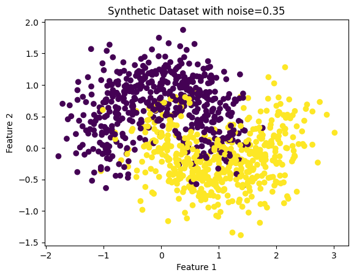

```python
# visualize the dataset
import matplotlib.pyplot as plt
plt.scatter(X_train[:,0], X_train[:,1], c=y_train)
plt.xlabel('Feature 1')
plt.ylabel('Feature 2')
plt.title('Synthetic Dataset with noise=0.35')
plt.show()
```

### 5.3

```python
subsets = []
classifiers = []
for i in range(3):
    # get random 100 points out of all data as subset
    indices = np.random.choice(range(X_train.shape[0]), size=100, replace=True)
    X_subset = X_train[indices]
    y_subset = y_train[indices]
    subsets.append((X_subset, y_subset))

    # fit kNN classifiers
    for k in [1, 25, 50]:
        knn = KNeighborsClassifier(n_neighbors=k)
        knn.fit(X_subset, y_subset)
        classifiers.append((knn, k, i))  # store classifier with its k and subset index
```

### 5.4

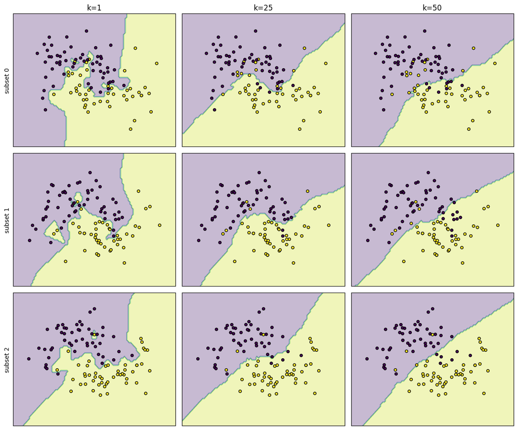

```python
# For each combination of dataset and trained classifier plot the decision boundary (similar in style to Figure 2.15 from Introduction to Statistical Learning). This should form a 3-by-3 grid. Each column should represent a different value of
# and each row should represent a different dataset.
def plot_grid(subsets, ks=(1, 25, 50), h=0.05):
    allX = np.vstack([Xs for Xs, _ in subsets])
    x_min, x_max = allX[:, 0].min() - 0.5, allX[:, 0].max() + 0.5
    y_min, y_max = allX[:, 1].min() - 0.5, allX[:, 1].max() + 0.5

    xx, yy = np.meshgrid(np.arange(x_min, x_max, h),
                         np.arange(y_min, y_max, h))
    grid = np.c_[xx.ravel(), yy.ravel()]

    fig, axes = plt.subplots(3, 3, figsize=(12, 10), sharex=True, sharey=True)

    for i, (Xs, ys) in enumerate(subsets):
        for j, k in enumerate(ks):
            ax = axes[i, j]
            knn = KNeighborsClassifier(n_neighbors=k).fit(Xs, ys)

            Z = knn.predict(grid).reshape(xx.shape)
            ax.contourf(xx, yy, Z, alpha=0.3)     # decision regions
            ax.scatter(Xs[:, 0], Xs[:, 1], c=ys, edgecolor="k", s=20)

            if i == 0: ax.set_title(f"k={k}")
            if j == 0: ax.set_ylabel(f"subset {i}")
            ax.set_xticks([]); ax.set_yticks([])

    plt.tight_layout()
    plt.show()
plot_grid(subsets, ks=(1, 25, 50))
```

### 5.5

What do you notice about the difference between the decision boundaries in the rows and the columns in your figure? Which decision boundaries appear to best separate the two classes of data with respect to the training data? Which decision boundaries vary the most as the training data change? Which decision boundaries do you anticipate will generalize best to unseen data and why?

**The rows just represent the 3 different random subsets of the data, so we should see similar patterns across rows. There is slight variance across rows which comes from the different datasets. For k=1, the boundaries change more dramtically between rows since tiny changes in the sample can produce different regions. For k=25, there is some variation across rows but the boundaries are stil pretty similar. For k=50, the boundaries are much more similar across rows and we get nearly the same diagonal split each time.**

**The columns represent the different k values (k = 1, 25, 50) which indicates how many nearest neighbors our KNN algorithm will look at. The plt above shows that for smaller k=1, the two clusters boundary are more defined as almost all of the yellow and black points are not overlapping, which makes sense when only looking at the single closest neighbor. This has a more complex decision boundary, however, this could be not generalizable and overfit when looking at new data.**

**For the middle column, k = 25, the boundary is a bit more smooth while still fitting most points and adapting to local structures.**

**For the right column, k = 50, the fit is more general, with very smooth and almost linear decision boundaries, not fully capturing the local structures and missing a few points.**

**K=1 separates the training data the best, but would likely generalize the worst to unseen data due to its overly complex boundaries that could cause overfitting. K=25 is more likely to generalize best due to a better bias–variance tradeoff.**

### 5.6

**The plots from earlier show the bias variance tradeoff by showing that k=1 produces more complex decision boundaries that vary more across the training subsets, showing low bias but high variance. The k=50 plot shows very smooth and stable boundaries across rows, suggesting high bias and low variance which can lead to underfitting. The middle value of k=25 shows a good balance between bias and variance, as it is flexible and stable, and can better generalize likely to unseen data.**

## Exercise 6: Bias-variance trade-off II: Quantifying the tradeoff

### 6.1

```python
X_test, y_test = make_moons(n_samples=1000, noise=0.35, random_state=23)
# X_test, y_test
```

### 6.2

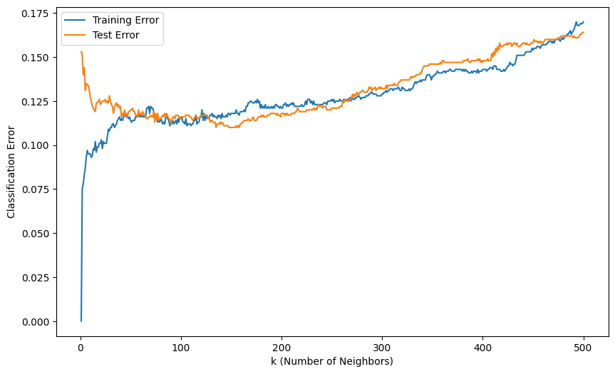

```python
train_errors = []
test_errors = []
for k in range(1, 501):
        knn = KNeighborsClassifier(n_neighbors=k)
        # apply to both training and test dataset and plot classification error
        knn.fit(X_train, y_train)
        y_train_pred = knn.predict(X_train)
        y_test_pred = knn.predict(X_test)
        train_error = 1 - accuracy(y_train, y_train_pred)
        test_error = 1 - accuracy(y_test, y_test_pred)

        train_errors.append(train_error)
        test_errors.append(test_error)

        # plot the classification error for both train and test on one plot

ks = range(1, 501)
plt.figure(figsize=(10, 6))
plt.plot(ks, train_errors, label="Training Error")
plt.plot(ks, test_errors, label="Test Error")
plt.xlabel("k (Number of Neighbors)")
plt.ylabel("Classification Error")
plt.legend()
plt.show()
```

### 6.3

As k increases, the training error increases while the test error initially decreases for lower k and then increases, forming a U shaped curve. This shows the bias variance tradeoff, as smaller k values overfit and larger values underfit.

### 6.5

To find optimal k, we want to see where test error is minimized and we can balance bias and variance. In this plot, this is around k=100 to 150, where there is a dip in the classification errors. Through computation in python by seeing when the test error is minimized, the best k is at k = 135 with test error of 0.1099.

### 6.6

In other models, other hyperparameters control the regularization or model flexibility. For linear regression, there is degree of polynomial features and regularization strength. For decision tree, there is max depth and min samples per leaf. For neural nets, there are number of layers, number of hidden units, regularization.

```python
ks = np.arange(1, 501)
best_idx = np.argmin(test_errors)
best_k = ks[best_idx]
best_test_error = test_errors[best_idx]

best_k, best_test_error
```

```
(np.int64(135), np.float64(0.10999999999999999))
```

## Exercise 7: Linear regression and nonlinear transformations

### 7.1

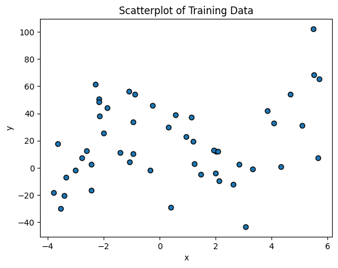

```python
q7_train = pd.read_csv('./A2_Q7_train.csv')
q7_test = pd.read_csv('./A2_Q7_test.csv')

# create scatterplot of data
plt.scatter(q7_train.x, q7_train.y, edgecolor='k')
plt.xlabel('x')
plt.ylabel('y')
plt.title('Scatterplot of Training Data')
plt.show()
```

### 7.2

```python
# linear regression model for training
from sklearn.linear_model import LinearRegression
from sklearn.metrics import r2_score, mean_squared_error
lin_reg = LinearRegression()
X_train = q7_train[['x']]
y_train_values = q7_train['y'].values
lin_reg.fit(X_train, y_train_values)

# calculate R squared for training data
y_train_pred = lin_reg.predict(X_train)

r_squared_train = r2_score(y_train_values, y_train_pred)
mse_train = mean_squared_error(y_train_values, y_train_pred)


# calculate mean squared error for training data

print(f"Training Data: R-squared = {r_squared_train}, MSE = {mse_train}")

# . Also provide the equation representing the estimated model (e.g. , but with the estimated coefficients inserted. from training fit
slope = lin_reg.coef_[0]
intercept = lin_reg.intercept_

print(f"Model: y = {slope} * x + {intercept}")
```

```
Training Data: R-squared = 0.06486123304769698, MSE = 791.4167471701106
Model: y = 2.5907282580761315 * x + 17.204928179405222
```

$\hat{y} = 2.5907\.x + 17.2049$

### 7.3

```python
# build model as y = a0 x + a1 x^2
# add x squared as a feature
x_train = np.asarray(q7_train[['x']]).reshape(-1, 1)
y_train = np.asarray( q7_train['y']).reshape(-1, )

Z_train = np.column_stack([
    x_train.ravel(),
    (x_train.ravel() ** 2)
])

model = LinearRegression()
model.fit(Z_train, y_train)

a0 = model.intercept_
a1, a2 = model.coef_

yhat_train = model.predict(Z_train)

r2_train = r2_score(y_train, yhat_train)
mse_train = mean_squared_error(y_train, yhat_train)


print(f"Training Data: R squared  = {r2_train:.4f}")
print(f"MSE  = {mse_train:.4f}")

print(f"Model: y_hat = {a0:.4f} + ({a1:.4f})*x + ({a2:.4f})*x^2")
```

```
Training Data: R squared  = 0.0853
MSE  = 774.1273
Model: y_hat = 12.9445 + (1.6056)*x + (0.5618)*x^2
```

**Model:**

$\hat{y} = 12.9445 + 1.6056\,x + 0.5618\,x^2$ `

### 7.4

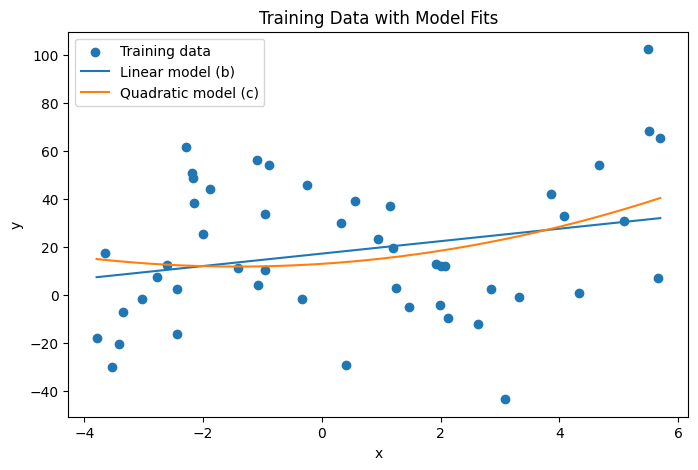

```
Linear model (b): y_hat = 17.2049 + (2.5907)*x
Quadratic model (c): y_hat = 12.9445 + (1.6056)*x + (0.5618)*x^2
```

```python
# visualize model fit to training data, plot iriginal data and both curves
import numpy as np
import matplotlib.pyplot as plt

x = q7_train["x"].values
y = q7_train["y"].values

x_grid = np.linspace(x.min(), x.max(), 400).reshape(-1, 1)

y_lin_curve = lin_reg.predict(x_grid)

Z_grid = np.column_stack([x_grid.ravel(), (x_grid.ravel() ** 2)])
y_quad_curve = model.predict(Z_grid)

plt.figure(figsize=(8, 5))
plt.scatter(x, y, label="Training data")
plt.plot(x_grid, y_lin_curve, label="Linear model (b)")
plt.plot(x_grid, y_quad_curve, label="Quadratic model (c)")
plt.xlabel("x")
plt.ylabel("y")
plt.title("Training Data with Model Fits")
plt.legend()
plt.show()

print(f"Linear model (b): y_hat = {intercept:.4f} + ({slope:.4f})*x")
print(f"Quadratic model (c): y_hat = {a0:.4f} + ({a1:.4f})*x + ({a2:.4f})*x^2")
```

### 7.5

```python
X_test = q7_test[['x']].values
y_test = q7_test['y'].values


y_test_pred_lin = lin_reg.predict(X_test)

r2_test_lin = r2_score(y_test, y_test_pred_lin)
mse_test_lin = mean_squared_error(y_test, y_test_pred_lin)

print("Linear model (b) – Test Data:")
print(f"R^2 = {r2_test_lin:.4f}")
print(f"MSE = {mse_test_lin:.4f}")
print()


x_test = np.asarray(X_test).reshape(-1, 1)

Z_test = np.column_stack([
    x_test.ravel(),
    x_test.ravel() ** 2
])

y_test_pred_quad = model.predict(Z_test)

r2_test_quad = r2_score(y_test, y_test_pred_quad)
mse_test_quad = mean_squared_error(y_test, y_test_pred_quad)

print("Quadratic model (c) – Test Data:")
print(f"R^2 = {r2_test_quad:.4f}")
print(f"MSE = {mse_test_quad:.4f}")
```

```
Linear model (b) – Test Data:
R^2 = -0.1329
MSE = 1116.6632

Quadratic model (c) – Test Data:
R^2 = -0.1203
MSE = 1104.2014
```

### 7.6: Model Performance Summary

| Dataset | Model | R² | MSE |
| --- | --- | --- | --- |
| Train | Linear | 0.0649 | 791.4167 |
| Train | Quadratic | 0.0853 | 774.1273 |
| Test | Linear | -0.1329 | 1116.6632 |
| Test | Quadratic | -0.1203 | 1104.2014 |

On the training data, the linear model has lower R squared than the transformed (quadratic) model and the transformed model has slightly lower Mean Squared Error, thus the transformed/quadratic model performs better than the linear model on the training data.

On the test data, the quadratic model has a slightly lower negative R squared and lower Mean Squared Error, thus performing better than the linear model on the test set.

These results make sense because the quadratic model is more flexible and can better fit the patterns in the training data. However, on the test set we see both models generalize poorly overal, so even while the quadratic model captures some nonlinearity, both models do not explain the variation in the new unseen data well. Both models already had low training R squared to begin with, and the negative test R squared means the relationship is very weak/noisy.

### 7.7

If the test data was very different from the training dataset, the models performance would decrease because during training, the model learned patterns specific to the training distribution. Then the generalization accuracy would decrease with higher MSE or lower/more negative R squared. This is because the model is not able to interpolate since the inputs in the test data would not look similar to the training data or follow similar distributions. Then, the model is unable to adapt and make confident predictions since it was not trained on data that looks like the test at all.

## Bonus

Implement a KNN with good accuracy latency tradeoff using Census Income dataset.

### Step 1: Load Data

```python
from ucimlrepo import fetch_ucirepo

# fetch dataset
adult = fetch_ucirepo(id=2)

# data (as pandas dataframes)
X = adult.data.features
y = adult.data.targets

# metadata
print(adult.metadata)

# variable information
print(adult.variables)
```

```
{'uci_id': 2, 'name': 'Adult', 'repository_url': 'https://archive.ics.uci.edu/dataset/2/adult', 'data_url': 'https://archive.ics.uci.edu/static/public/2/data.csv', 'abstract': 'Predict whether annual income of an individual exceeds $50K/yr based on census data. Also known as "Census Income" dataset.…
              name     role         type      demographic  \
0              age  Feature      Integer              Age
1        workclass  Feature  Categorical           Income
2           fnlwgt  Feature      Integer             None
3        education  Feature  Categorical  Education Level
4    education-num  Feature      Integer  Education Level
5   marital-status  Feature  Categorical            Other
6       occupation  Feature  Categorical            Other
7     relationship  Feature  Categorical            Other
8             race  Feature  Categorical             Race
9              sex  Feature       Binary              Sex
10    capital-gain  Feature      Integer             None
11    capital-loss  Feature      Integer             None
12  hours-per-week  Feature      Integer             None
```

[output cut: 19 more lines]

```python
df = pd.concat([X, y], axis=1)
df.head()
```

|  | age | workclass | fnlwgt | education | education-num | marital-status | occupation | relationship | race | sex | capital-gain | capital-loss | hours-per-week | native-country | income |
| --- | --- | --- | --- | --- | --- | --- | --- | --- | --- | --- | --- | --- | --- | --- | --- |
| 0 | 39 | State-gov | 77516 | Bachelors | 13 | Never-married | Adm-clerical | Not-in-family | White | Male | 2174 | 0 | 40 | United-States | <=50K |
| 1 | 50 | Self-emp-not-inc | 83311 | Bachelors | 13 | Married-civ-spouse | Exec-managerial | Husband | White | Male | 0 | 0 | 13 | United-States | <=50K |
| 2 | 38 | Private | 215646 | HS-grad | 9 | Divorced | Handlers-cleaners | Not-in-family | White | Male | 0 | 0 | 40 | United-States | <=50K |
| 3 | 53 | Private | 234721 | 11th | 7 | Married-civ-spouse | Handlers-cleaners | Husband | Black | Male | 0 | 0 | 40 | United-States | <=50K |
| 4 | 28 | Private | 338409 | Bachelors | 13 | Married-civ-spouse | Prof-specialty | Wife | Black | Female | 0 | 0 | 40 | Cuba | <=50K |

### Step 2: EDA

```
(48842, 15)
income
<=50K     24720
<=50K.    12435
>50K       7841
>50K.      3846
Name: count, dtype: int64
```

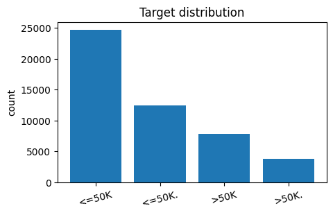

```
Top missing columns:
 occupation        0.019778
workclass         0.019717
native-country    0.005610
fnlwgt            0.000000
education         0.000000
education-num     0.000000
age               0.000000
marital-status    0.000000
relationship      0.000000
sex               0.000000
dtype: float64
```

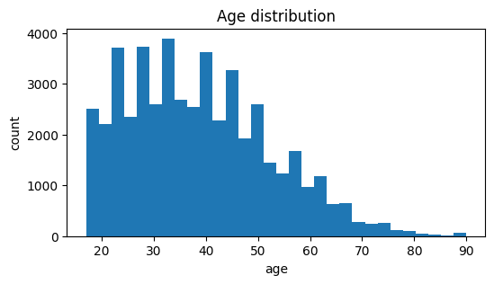

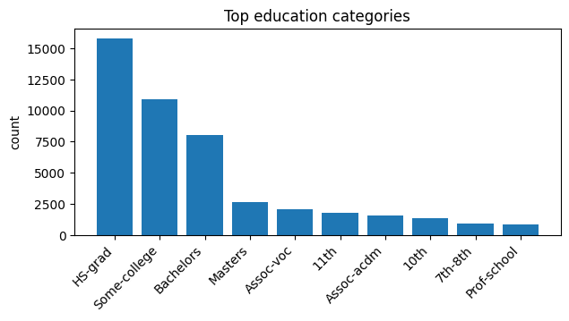

```python
print(df.shape)
print(df["income"].value_counts(dropna=False))

# view balance of income column
counts = df["income"].value_counts()
plt.figure(figsize=(5,3))
plt.bar(counts.index.astype(str), counts.values)
plt.title("Target distribution")
plt.ylabel("count")
plt.xticks(rotation=15)
plt.show()

# see missing values of top 10 columns
missing = df.isna().mean().sort_values(ascending=False)
print("Top missing columns:\n", missing.head(10))

# distribution of age
plt.figure(figsize=(6,3))
plt.hist(df["age"].dropna(), bins=30)
plt.title("Age distribution")
plt.xlabel("age")
plt.ylabel("count")
plt.show()

# distribution of agw
edu_counts = df["education"].value_counts().head(10)
plt.figure(figsize=(7,3))
plt.bar(edu_counts.index.astype(str), edu_counts.values)
plt.title("Top education categories")
plt.xticks(rotation=45, ha="right")
plt.ylabel("count")
plt.show()
```

### Step 3: Preprocessing

```python
from sklearn.model_selection import train_test_split
from sklearn.compose import ColumnTransformer
from sklearn.pipeline import Pipeline
from sklearn.preprocessing import OneHotEncoder, StandardScaler
from sklearn.impute import SimpleImputer
from sklearn.decomposition import TruncatedSVD

# Separate X/y
y = (df["income"].astype(str).str.contains(">50K")).astype(int)
X = df.drop(columns=["income"])

# Identify column types
numeric_cols = X.select_dtypes(include=[np.number]).columns.tolist()
categorical_cols = [c for c in X.columns if c not in numeric_cols]

X_train, X_test, y_train, y_test = train_test_split(
    X, y, test_size=0.25, random_state=42, stratify=y
)

numeric_pipe = Pipeline([
    ("imputer", SimpleImputer(strategy="median")),
    ("scaler", StandardScaler())
])

categorical_pipe = Pipeline([
    ("imputer", SimpleImputer(strategy="most_frequent")),
    ("onehot", OneHotEncoder(handle_unknown="ignore"))
])

preprocess = ColumnTransformer([
    ("num", numeric_pipe, numeric_cols),
    ("cat", categorical_pipe, categorical_cols)
], remainder="drop")
```

### Step 4: Evaluation and Baseline

```python
import time
from sklearn.metrics import accuracy_score, f1_score

def evaluate_model(model, X_train, y_train, X_test, y_test, timing_reps=5):
    # fit
    model.fit(X_train, y_train)

    # predict metrics
    yhat = model.predict(X_test)
    acc = accuracy_score(y_test, yhat)
    f1 = f1_score(y_test, yhat)

    # latency: average ms per prediction
    times = []
    for _ in range(timing_reps):
        t0 = time.perf_counter()
        _ = model.predict(X_test)
        t1 = time.perf_counter()
        times.append(t1 - t0)

    avg_time = float(np.mean(times))
    ms_per_pred = 1000.0 * avg_time / len(X_test)

    return {"accuracy": acc, "f1": f1, "ms_per_pred": ms_per_pred}
```

```python
from sklearn.neighbors import KNeighborsClassifier

baseline_knn = Pipeline([
    ("prep", preprocess),
    ("knn", KNeighborsClassifier(n_neighbors=25))
])

baseline_results = evaluate_model(baseline_knn, X_train, y_train, X_test, y_test)
baseline_results
```

```
{'accuracy': 0.84612234870199,
 'f1': 0.6522302424578937,
 'ms_per_pred': 1.0809216135444502}
```

### Step 5: Experiment

#### Vary Values of K

```python
k_values = [1, 5, 15, 25, 50, 100]
rows = []

for k in k_values:
    model = Pipeline([
        ("prep", preprocess),
        ("knn", KNeighborsClassifier(n_neighbors=k))
    ])
    out = evaluate_model(model, X_train, y_train, X_test, y_test)
    out.update({"setting": "vary_k", "k": k})
    rows.append(out)

res_k = pd.DataFrame(rows)
res_k
```

|  | accuracy | f1 | ms_per_pred | setting | k |
| --- | --- | --- | --- | --- | --- |
| 0 | 0.800344 | 0.584809 | 0.947976 | vary_k | 1 |
| 1 | 0.831136 | 0.628468 | 1.088804 | vary_k | 5 |
| 2 | 0.845222 | 0.651677 | 1.132744 | vary_k | 15 |
| 3 | 0.846122 | 0.652230 | 1.233352 | vary_k | 25 |
| 4 | 0.844976 | 0.640729 | 1.265776 | vary_k | 50 |
| 5 | 0.844812 | 0.637875 | 1.195947 | vary_k | 100 |

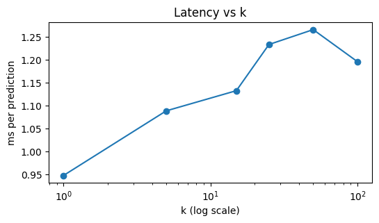

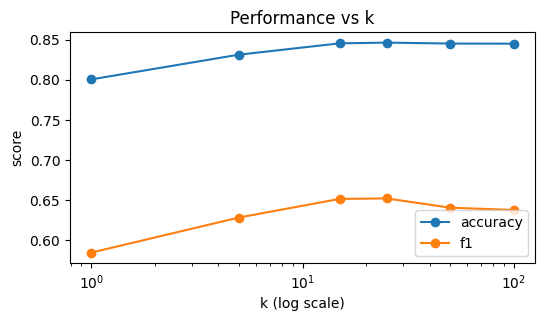

```python
plt.figure(figsize=(6,3))
plt.plot(res_k["k"], res_k["ms_per_pred"], marker="o")
plt.xscale("log")
plt.xlabel("k (log scale)")
plt.ylabel("ms per prediction")
plt.title("Latency vs k")
plt.show()

plt.figure(figsize=(6,3))
plt.plot(res_k["k"], res_k["accuracy"], marker="o", label="accuracy")
plt.plot(res_k["k"], res_k["f1"], marker="o", label="f1")
plt.xscale("log")
plt.xlabel("k (log scale)")
plt.ylabel("score")
plt.title("Performance vs k")
plt.legend()
plt.show()
```

#### Vary training size (subsample training set)

```python
from sklearn.utils import resample

fractions = [0.1, 0.25, 0.5, 0.75, 1.0]
k_fixed = 25
rows = []

for frac in fractions:
    X_sub, y_sub = resample(X_train, y_train, n_samples=int(frac * len(X_train)), random_state=42, stratify=y_train)

    model = Pipeline([
        ("prep", preprocess),
        ("knn", KNeighborsClassifier(n_neighbors=k_fixed))
    ])

    out = evaluate_model(model, X_sub, y_sub, X_test, y_test)
    out.update({"setting": "vary_train_frac", "train_frac": frac, "k": k_fixed})
    rows.append(out)

res_frac = pd.DataFrame(rows)
res_frac
```

|  | accuracy | f1 | ms_per_pred | setting | train_frac | k |
| --- | --- | --- | --- | --- | --- | --- |
| 0 | 0.830972 | 0.617636 | 0.123811 | vary_train_frac | 0.10 | 25 |
| 1 | 0.837032 | 0.628870 | 0.285053 | vary_train_frac | 0.25 | 25 |
| 2 | 0.840472 | 0.640458 | 0.569065 | vary_train_frac | 0.50 | 25 |
| 3 | 0.838752 | 0.639707 | 0.855794 | vary_train_frac | 0.75 | 25 |
| 4 | 0.839407 | 0.639853 | 1.131323 | vary_train_frac | 1.00 | 25 |

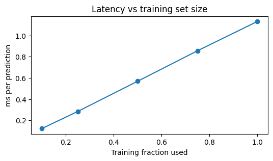

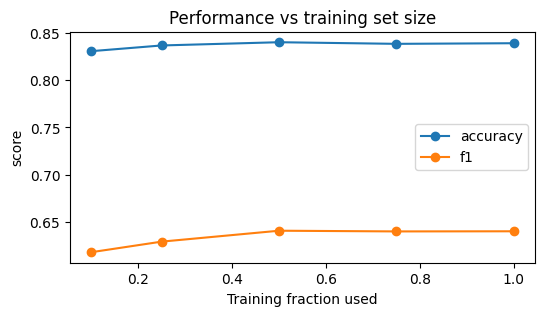

```python
plt.figure(figsize=(6,3))
plt.plot(res_frac["train_frac"], res_frac["ms_per_pred"], marker="o")
plt.xlabel("Training fraction used")
plt.ylabel("ms per prediction")
plt.title("Latency vs training set size")
plt.show()

plt.figure(figsize=(6,3))
plt.plot(res_frac["train_frac"], res_frac["accuracy"], marker="o", label="accuracy")
plt.plot(res_frac["train_frac"], res_frac["f1"], marker="o", label="f1")
plt.xlabel("Training fraction used")
plt.ylabel("score")
plt.title("Performance vs training set size")
plt.legend()
plt.show()
```

#### Vary Number of Features

```python
svd_components = [10, 25, 50, 100]
k_fixed = 25
rows = []

for d in svd_components:
    model = Pipeline([
        ("prep", preprocess),
        ("svd", TruncatedSVD(n_components=d, random_state=42)),
        ("knn", KNeighborsClassifier(n_neighbors=k_fixed))
    ])

    out = evaluate_model(model, X_train, y_train, X_test, y_test)
    out.update({"setting": "vary_svd", "svd_components": d, "k": k_fixed})
    rows.append(out)

res_svd = pd.DataFrame(rows)
res_svd
```

|  | accuracy | f1 | ms_per_pred | setting | svd_components | k |
| --- | --- | --- | --- | --- | --- | --- |
| 0 | 0.843010 | 0.636725 | 0.137045 | vary_svd | 10 | 25 |
| 1 | 0.844321 | 0.640303 | 0.058087 | vary_svd | 25 | 25 |
| 2 | 0.845631 | 0.650213 | 0.068517 | vary_svd | 50 | 25 |
| 3 | 0.846122 | 0.652230 | 0.099278 | vary_svd | 100 | 25 |

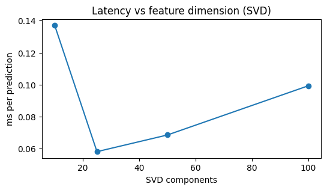

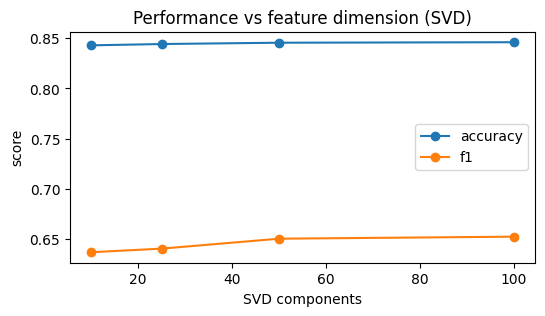

```python
plt.figure(figsize=(6,3))
plt.plot(res_svd["svd_components"], res_svd["ms_per_pred"], marker="o")
plt.xlabel("SVD components")
plt.ylabel("ms per prediction")
plt.title("Latency vs feature dimension (SVD)")
plt.show()

plt.figure(figsize=(6,3))
plt.plot(res_svd["svd_components"], res_svd["accuracy"], marker="o", label="accuracy")
plt.plot(res_svd["svd_components"], res_svd["f1"], marker="o", label="f1")
plt.xlabel("SVD components")
plt.ylabel("score")
plt.title("Performance vs feature dimension (SVD)")
plt.legend()
plt.show()
```

```python
all_results = pd.concat([
    res_k.assign(train_frac=np.nan, svd_components=np.nan),
    res_frac.assign(k=k_fixed, svd_components=np.nan),
    res_svd.assign(train_frac=np.nan)
], ignore_index=True)

all_results.sort_values(["ms_per_pred"], ascending=True).head(15)
```

|  | accuracy | f1 | ms_per_pred | setting | k | train_frac | svd_components |
| --- | --- | --- | --- | --- | --- | --- | --- |
| 12 | 0.844321 | 0.640303 | 0.058087 | vary_svd | 25 | NaN | 25.0 |
| 13 | 0.845631 | 0.650213 | 0.068517 | vary_svd | 25 | NaN | 50.0 |
| 14 | 0.846122 | 0.652230 | 0.099278 | vary_svd | 25 | NaN | 100.0 |
| 6 | 0.830972 | 0.617636 | 0.123811 | vary_train_frac | 25 | 0.10 | NaN |
| 11 | 0.843010 | 0.636725 | 0.137045 | vary_svd | 25 | NaN | 10.0 |
| 7 | 0.837032 | 0.628870 | 0.285053 | vary_train_frac | 25 | 0.25 | NaN |
| 8 | 0.840472 | 0.640458 | 0.569065 | vary_train_frac | 25 | 0.50 | NaN |
| 9 | 0.838752 | 0.639707 | 0.855794 | vary_train_frac | 25 | 0.75 | NaN |
| 0 | 0.800344 | 0.584809 | 0.947976 | vary_k | 1 | NaN | NaN |
| 1 | 0.831136 | 0.628468 | 1.088804 | vary_k | 5 | NaN | NaN |
| 10 | 0.839407 | 0.639853 | 1.131323 | vary_train_frac | 25 | 1.00 | NaN |
| 2 | 0.845222 | 0.651677 | 1.132744 | vary_k | 15 | NaN | NaN |
| 5 | 0.844812 | 0.637875 | 1.195947 | vary_k | 100 | NaN | NaN |
| 3 | 0.846122 | 0.652230 | 1.233352 | vary_k | 25 | NaN | NaN |
| 4 | 0.844976 | 0.640729 | 1.265776 | vary_k | 50 | NaN | NaN |

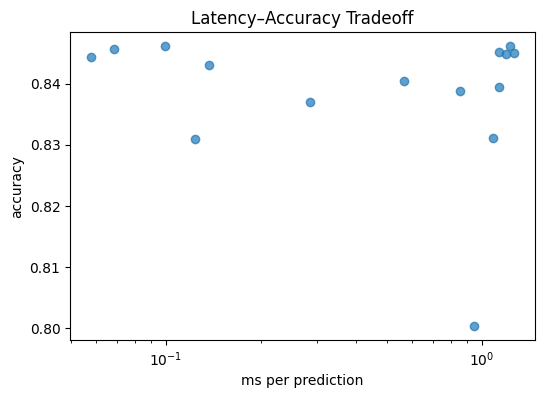

```python
plt.figure(figsize=(6,4))
plt.scatter(all_results["ms_per_pred"], all_results["accuracy"], alpha=0.7)
plt.xlabel("ms per prediction")
plt.ylabel("accuracy")
plt.title("Latency–Accuracy Tradeoff")
plt.xscale("log")
plt.show()
```

### Final Conclusion

In this analysis, I explored the tradeoff between prediction latency and model performance for a k-Nearest Neighbors classifier on the Census Income dataset. By varying the number of neighbors, the size of the training data, and the number of features through dimensionality reduction, I found that feature dimensionality is the dominant factor affecting inference latency. Applying TruncatedSVD to reduce the one-hot encoded feature space led to more than an order-of-magnitude reduction in prediction time, while accuracy and F1 score remained largely stable.

```python
!jupyter nbconvert --to html hw2.ipynb --TemplateExporter.exclude_input_prompt=True
```